**Relationship between Europeans’ trust in political institutions and their attitude to government surveillance**

*Modern Social Analysis, HSE SPb (Course Thesis)*

**Vasily Khodakovsky**

# Data

#### [5th wave of European Values Study (EVS)](https://europeanvaluesstudy.eu/)

```r
library(plyr)
library(dplyr)
library(kableExtra)
```

```r
library(foreign)
EVS_raw <- read.spss("C:/Users/Vasily/Downloads/EVS.sav",
                     use.value.labels = T, to.data.frame = T)
```

### Countries

```r
table(EVS_raw$country) %>%
  as.data.frame() %>%
  setNames(c("Countries", "Number of respondents")) %>%
  kbl() %>%
  kable_classic(html_font = "Cambria")
```

| Countries | Number of respondents |
| --- | --- |
| Albania | 1435 |
| Azerbaijan | 1800 |
| Austria | 1644 |
| Armenia | 1500 |
| Bosnia and Herzegovina | 1724 |
| Bulgaria | 1558 |
| Belarus | 1548 |
| Croatia | 1487 |
| Czechia | 1811 |
| Denmark | 3362 |
| Estonia | 1304 |
| Finland | 1199 |
| France | 1870 |
| Georgia | 2194 |
| Germany | 2170 |
| Greece | 0 |
| Hungary | 1514 |
| Iceland | 1624 |
| Italy | 2277 |
| Lithuania | 1448 |
| Montenegro | 1003 |
| Netherlands | 2404 |
| Norway | 1122 |
| Poland | 1352 |
| Portugal | 1215 |
| Romania | 1613 |
| Russia | 1825 |
| Serbia | 1499 |
| Slovakia | 1432 |
| Slovenia | 1075 |
| Spain | 1209 |
| Sweden | 1194 |
| Switzerland | 3174 |
| North Macedonia | 1117 |
| Great Britain | 1788 |

#### Creating new variable `part`, that indicates is country ex-socialist or not (Eastern Europe or not):

```r
EVS_raw$part <- "West"

countries_part <- c("Albania", "Armenia", "Azerbaijan",
                    "Belarus", "Bosnia and Herzegovina", "Bulgaria",
                    "Croatia", "Czechia", "Estonia",
                    "Georgia", "Hungary", "Lithuania",
                    "Montenegro", "North Macedonia", "Poland",
                    "Romania", "Russia", "Serbia",
                    "Slovakia", "Slovenia")

EVS_raw <- EVS_raw %>%
  mutate(part = ifelse(country %in% countries_part, "East", part))


EVS_raw$part = as.factor(EVS_raw$part)
```

```r
table(EVS_raw$part) %>%
  as.data.frame() %>%
  setNames(c("Part of Europe", "Number of respondents")) %>%
  kbl() %>%
  kable_classic(html_font = "Cambria")
```

| Part of Europe | Number of respondents |
| --- | --- |
| East | 30239 |
| West | 26252 |

### Trust in political institutions

#### Q38G) Parliament:

```r
table(EVS_raw$v121) %>%
  as.data.frame() %>%
  setNames(c("Level of confidence in parliament", "Number of respondents")) %>%
  kbl() %>%
  kable_classic(html_font = "Cambria")
```

| Level of confidence in parliament | Number of respondents |
| --- | --- |
| a great deal | 2837 |
| quite a lot | 16839 |
| not very much | 22439 |
| none at all | 12395 |

```r
EVS_raw$v121 <- dplyr::recode(EVS_raw$v121,
                              "a great deal" = 4,
                              "quite a lot" = 3,
                              "not very much" = 2,
                              "none at all" = 1)
```

```r
EVS_raw$v121 <- as.numeric(EVS_raw$v121)
```

```r
table(EVS_raw$v121) %>%
  as.data.frame() %>%
  setNames(c("Level of confidence in parliament", "Number of respondents")) %>%
  kbl() %>%
  kable_classic(html_font = "Cambria")
```

| Level of confidence in parliament | Number of respondents |
| --- | --- |
| 1 | 12395 |
| 2 | 22439 |
| 3 | 16839 |
| 4 | 2837 |

#### Q38H) Civil service:

```r
table(EVS_raw$v122) %>%
  as.data.frame() %>%
  setNames(c("Level of confidence in civil service", "Number of respondents")) %>%
  kbl() %>%
  kable_classic(html_font = "Cambria")
```

| Level of confidence in civil service | Number of respondents |
| --- | --- |
| a great deal | 3332 |
| quite a lot | 23153 |
| not very much | 21394 |
| none at all | 6529 |

```r
EVS_raw$v122 <- dplyr::recode(EVS_raw$v122,
                              "a great deal" = 4,
                              "quite a lot" = 3,
                              "not very much" = 2,
                              "none at all" = 1)
```

```r
EVS_raw$v122 <- as.numeric(EVS_raw$v122)
```

```r
table(EVS_raw$v122) %>%
  as.data.frame() %>%
  setNames(c("Level of confidence in civil service", "Number of respondents")) %>%
  kbl() %>%
  kable_classic(html_font = "Cambria")
```

| Level of confidence in civil service | Number of respondents |
| --- | --- |
| 1 | 6529 |
| 2 | 21394 |
| 3 | 23153 |
| 4 | 3332 |

#### Q38Q) Government:

```r
table(EVS_raw$v131) %>%
  as.data.frame() %>%
  setNames(c("Level of confidence in government", "Number of respondents")) %>%
  kbl() %>%
  kable_classic(html_font = "Cambria")
```

| Level of confidence in government | Number of respondents |
| --- | --- |
| a great deal | 3359 |
| quite a lot | 17190 |
| not very much | 21343 |
| none at all | 12770 |

```r
EVS_raw$v131 <- dplyr::recode(EVS_raw$v131,
                              "a great deal" = 4,
                              "quite a lot" = 3,
                              "not very much" = 2,
                              "none at all" = 1)
```

```r
EVS_raw$v131 <- as.numeric(EVS_raw$v131)
```

```r
table(EVS_raw$v131) %>%
  as.data.frame() %>%
  setNames(c("Level of confidence in government", "Number of respondents")) %>%
  kbl() %>%
  kable_classic(html_font = "Cambria")
```

| Level of confidence in government | Number of respondents |
| --- | --- |
| 1 | 12770 |
| 2 | 21343 |
| 3 | 17190 |
| 4 | 3359 |

#### Index:

Creating Political Trust Index

```r
EVS_raw$polit <- (EVS_raw$v121 + EVS_raw$v122 + EVS_raw$v131)/3
```

##### Cronbach’s alpha of the index

```r
library(ltm)
polit_cronbach <- EVS_raw %>% dplyr::select(v121, v122, v131)
cronbach.alpha(polit_cronbach, na.rm = T)
```

```
##
## Cronbach's alpha for the 'polit_cronbach' data-set
##
## Items: 3
## Sample units: 56491
## alpha: 0.809
```

Level of Cronbach’s alpha is fine.

### Surveillance

#### Q58A) Should the government have the right to keep people under video surveillance in public areas:

```r
table(EVS_raw$v205) %>%
  as.data.frame() %>%
  setNames(c("Attitude to the video surveillance", "Number of respondents")) %>%
  kbl() %>%
  kable_classic(html_font = "Cambria")
```

| Attitude to the video surveillance | Number of respondents |
| --- | --- |
| definitely should have the right | 15323 |
| probably should have the right | 19275 |
| probably should not have the right | 9361 |
| definitely should not have the right | 11102 |

```r
EVS_raw$v205 <- dplyr::recode(EVS_raw$v205,
                              "definitely should have the right" = 4,
                              "probably should have the right" = 3,
                              "probably should not have the right" = 2,
                              "definitely should not have the right" = 1)
```

```r
EVS_raw$v205 <- as.numeric(EVS_raw$v205)
```

```r
table(EVS_raw$v205) %>%
  as.data.frame() %>%
  setNames(c("Attitude to the video surveillance", "Number of respondents")) %>%
  kbl() %>%
  kable_classic(html_font = "Cambria")
```

| Attitude to the video surveillance | Number of respondents |
| --- | --- |
| 1 | 11102 |
| 2 | 9361 |
| 3 | 19275 |
| 4 | 15323 |

#### Q58B) Should the government have the right to monitor all e-mails and any other information exchanged on the Internet:

```r
table(EVS_raw$v206) %>%
  as.data.frame() %>%
  setNames(c("Attitude to the internet surveillance", "Number of respondents")) %>%
  kbl() %>%
  kable_classic(html_font = "Cambria")
```

| Attitude to the internet surveillance | Number of respondents |
| --- | --- |
| definitely should have the right | 3777 |
| probably should have the right | 9567 |
| probably should not have the right | 15711 |
| definitely should not have the right | 25113 |

```r
EVS_raw$v206 <- dplyr::recode(EVS_raw$v206,
                              "definitely should have the right" = 4,
                              "probably should have the right" = 3,
                              "probably should not have the right" = 2,
                              "definitely should not have the right" = 1)
```

```r
EVS_raw$v206 <- as.numeric(EVS_raw$v206)
```

```r
table(EVS_raw$v206) %>%
  as.data.frame() %>%
  setNames(c("Attitude to the internet surveillance", "Number of respondents")) %>%
  kbl() %>%
  kable_classic(html_font = "Cambria")
```

| Attitude to the internet surveillance | Number of respondents |
| --- | --- |
| 1 | 25113 |
| 2 | 15711 |
| 3 | 9567 |
| 4 | 3777 |

#### Q58C) Should the government have the right to collect information about anyone living in the country without their knowledge:

```r
table(EVS_raw$v207) %>%
  as.data.frame() %>%
  setNames(c("Attitude to collecting information about anyone", "Number of respondents")) %>%
  kbl() %>%
  kable_classic(html_font = "Cambria")
```

| Attitude to collecting information about anyone | Number of respondents |
| --- | --- |
| definitely should have the right | 3800 |
| probably should have the right | 8691 |
| probably should not have the right | 13869 |
| definitely should not have the right | 28255 |

```r
EVS_raw$v207 <- dplyr::recode(EVS_raw$v207,
                              "definitely should have the right" = 4,
                              "probably should have the right" = 3,
                              "probably should not have the right" = 2,
                              "definitely should not have the right" = 1)
```

```r
EVS_raw$v207 <- as.numeric(EVS_raw$v207)
```

```r
table(EVS_raw$v207) %>%
  as.data.frame() %>%
  setNames(c("Attitude to the collecting information about anyone", "Number of respondents")) %>%
  kbl() %>%
  kable_classic(html_font = "Cambria")
```

| Attitude to the collecting information about anyone | Number of respondents |
| --- | --- |
| 1 | 28255 |
| 2 | 13869 |
| 3 | 8691 |
| 4 | 3800 |

#### Index:

Creating Surveillance Attitude Index

```r
EVS_raw$surv <- (EVS_raw$v205 + EVS_raw$v206 + EVS_raw$v207)/3
```

##### Cronbach’s alpha of the index

```r
surv_cronbach <- EVS_raw %>% dplyr::select(v205, v206, v207)
cronbach.alpha(surv_cronbach, na.rm = T)
```

```
##
## Cronbach's alpha for the 'surv_cronbach' data-set
##
## Items: 3
## Sample units: 56491
## alpha: 0.727
```

Level of Cronbach’s alpha is fine.

### Gender

```r
table(EVS_raw$v225) %>%
  as.data.frame() %>%
  setNames(c("Gender", "Number of respondents")) %>%
  kbl() %>%
  kable_classic(html_font = "Cambria")
```

| Gender | Number of respondents |
| --- | --- |
| male | 25227 |
| female | 31238 |

#### Renaming variable:

```r
EVS_raw$gender <- EVS_raw$v225
```

### Education

```r
table(EVS_raw$v243_r) %>%
  as.data.frame() %>%
  setNames(c("Education category", "Number of respondents")) %>%
  kbl() %>%
  kable_classic(html_font = "Cambria")
```

| Education category | Number of respondents |
| --- | --- |
| lower | 11779 |
| medium | 25611 |
| higher | 18649 |
| other | 84 |

#### Deleting “other” education because it has small proportion:

```r
EVS_raw <- EVS_raw %>% filter(v243_r == "lower" |
                              v243_r == "medium" |
                              v243_r == "higher")
EVS_raw <- EVS_raw[!EVS_raw$v243_r == "other",]
EVS_raw$v243_r = droplevels(EVS_raw$v243_r)
```

```r
table(EVS_raw$v243_r) %>%
  as.data.frame() %>%
  setNames(c("Education category", "Number of respondents")) %>%
  kbl() %>%
  kable_classic(html_font = "Cambria")
```

| Education category | Number of respondents |
| --- | --- |
| lower | 11779 |
| medium | 25611 |
| higher | 18649 |

#### Renaming variable:

```r
EVS_raw$education <- EVS_raw$v243_r
```

### Income

Three categories, depend on the income in the country

```r
table(EVS_raw$v261_r) %>%
  as.data.frame() %>%
  setNames(c("Income category", "Number of respondents")) %>%
  kbl() %>%
  kable_classic(html_font = "Cambria")
```

| Income category | Number of respondents |
| --- | --- |
| Low | 16009 |
| Middle | 16267 |
| High | 15474 |

#### Renaming variable:

```r
EVS_raw$income <- EVS_raw$v261_r
```

### Size of town

```r
table(EVS_raw$v276_r) %>%
  as.data.frame() %>%
  setNames(c("Size of town", "Number of respondents")) %>%
  kbl() %>%
  kable_classic(html_font = "Cambria")
```

| Size of town | Number of respondents |
| --- | --- |
| under 5000 | 14194 |
| 5000-20000 | 11231 |
| 20000-100000 | 10456 |
| 100000-500000 | 8161 |
| 500000 and more | 6169 |

#### Renaming variable:

```r
EVS_raw$size_town <- EVS_raw$v276_r
```

### Age

```r
data.frame(c("Min", "Max"),
           c(head(levels(EVS_raw$age))[1], tail(levels(EVS_raw$age))[6])) %>%
  as.data.frame() %>%
  setNames(c("Age", " ")) %>%
  kbl() %>%
  kable_classic(html_font = "Cambria")
```

| Age |  |
| --- | --- |
| Min | 18 |
| Max | 82 and older |

```r
EVS_raw$age = mapvalues(EVS_raw$age, from = c("82 and older"), to = c("82"))
detach("package:plyr", unload=TRUE)

EVS_raw$age <-as.numeric(as.character(EVS_raw$age))

summary(EVS_raw$age)
```

```
##    Min. 1st Qu.  Median    Mean 3rd Qu.    Max.    NA's
##   18.00   35.00   50.00   49.64   64.00   82.00     281
```

### Final dataset

```r
EVS <- EVS_raw %>% dplyr::select(country, part,
                                 polit, surv,
                                 gender, age,
                                 education, income,
                                 size_town)

summary(EVS)
```

```
##         country        part           polit            surv
##  Denmark    : 3283   East:30076   Min.   :1.000   Min.   :1.000
##  Switzerland: 3122   West:25963   1st Qu.:1.667   1st Qu.:1.667
##  Netherlands: 2369                Median :2.333   Median :2.000
##  Italy      : 2264                Mean   :2.273   Mean   :2.109
##  Georgia    : 2192                3rd Qu.:3.000   3rd Qu.:2.667
##  Germany    : 2152                Max.   :4.000   Max.   :4.000
##  (Other)    :40657                NA's   :3805    NA's   :3191
##     gender           age         education        income
##  male  :25002   Min.   :18.00   lower :11779    Low  :16009
##  female:31026   1st Qu.:35.00   medium:25611   Middle:16267
##  NA's  :   11   Median :50.00   higher:18649   High  :15474
##                 Mean   :49.64                  NA's  : 8289
##                 3rd Qu.:64.00
##                 Max.   :82.00
##                 NA's   :281
##            size_town
##  under 5000     :14194
##  5000-20000     :11231
##  20000-100000   :10456
##  100000-500000  : 8161
##  500000 and more: 6169
##  NA's           : 5828
##
```

# Exploratory Analysis

### Descriptive Statistics

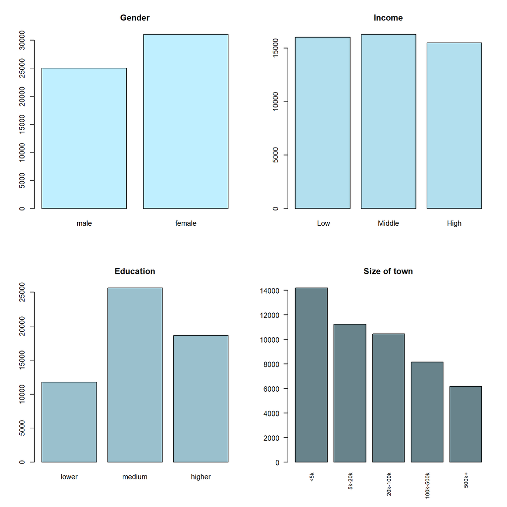

```r
par(mfrow = c(2,2))
plot(EVS$gender, col = "lightblue1", main = "Gender")
plot(EVS$income, col = "lightblue2", main = "Income")
plot(EVS$education, col = "lightblue3", main = "Education")
plot(EVS$size_town, col = "lightblue4",
     names.arg = c("<5k", "5k-20k", "20k-100k", "100k-500k", "500k+"),
     las = 2,
     cex.names = 0.8,
     main = "Size of town",)
```

```r
library(psych)
round(describe(EVS[c("polit", "surv", "age")]),2) %>%
  dplyr::select(min, max, mean, median, sd) %>%
  as.data.frame() %>%
  setNames(c("Min", "Max", "Mean", "Median", "SD")) %>%
  kbl() %>%
  kable_classic(html_font = "Cambria")
```

|  | Min | Max | Mean | Median | SD |
| --- | --- | --- | --- | --- | --- |
| polit | 1 | 4 | 2.27 | 2.33 | 0.71 |
| surv | 1 | 4 | 2.11 | 2.00 | 0.80 |
| age | 18 | 82 | 49.64 | 50.00 | 17.71 |

#### Age:

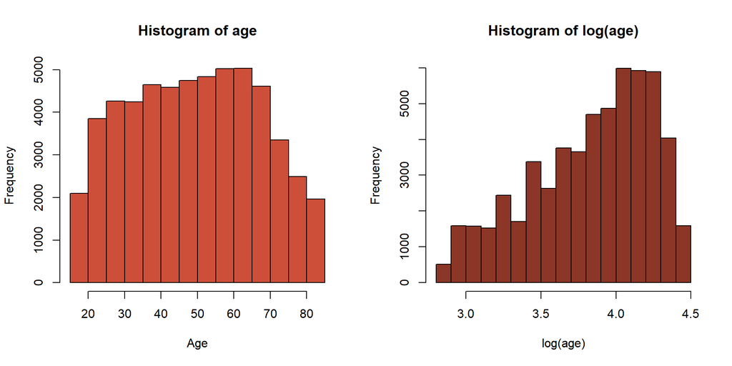

```r
par(mfrow = c(1,2))
hist(EVS$age, col = "tomato3", xlab = "Age", main = "Histogram of age")
hist(log(EVS$age), col = "tomato4", xlab = "log(age)", main = "Histogram of log(age)")
```

```r
summary(EVS$age)
```

```
##    Min. 1st Qu.  Median    Mean 3rd Qu.    Max.    NA's
##   18.00   35.00   50.00   49.64   64.00   82.00     281
```

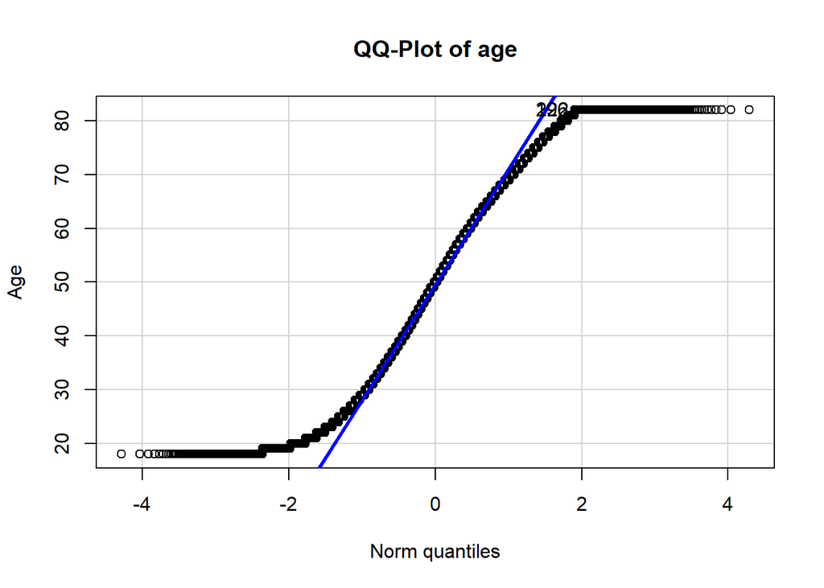

```
## [1] 196 222
```

```r
library(car)
qqPlot(EVS$age, xlab = "Norm quantiles", ylab = "Age", main = "QQ-Plot of age")
```

#### Surveillance Attitude Index and Political Trust Index:

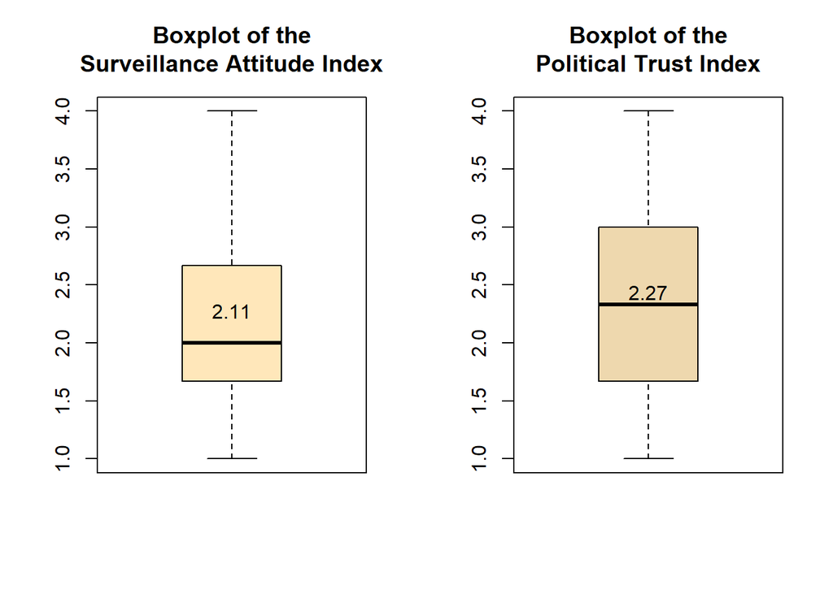

```r
par(mfrow = c(1, 2))

boxplot(EVS$surv, col = "wheat1", main = "Boxplot of the\nSurveillance Attitude Index")
mean_surv <- mean(EVS$surv, na.rm = T)
text(x = 1, y = mean_surv, labels = paste0(round(mean_surv, 2)), pos = 3)

boxplot(EVS$polit, col = "wheat2", main = "Boxplot of the\nPolitical Trust Index")
mean_polit <- mean(EVS$polit, na.rm = T)
text(x = 1, y = mean_polit, labels = paste0(round(mean_polit, 2)), pos = 3)
```

### Surveillance Attitude map

```r
averages <- aggregate(surv ~ country, data = EVS, FUN = function(x) round(mean(x), 2))
averages %>%
  setNames(c("Country", "Surveillance Attitude Index")) %>%
  kbl() %>%
  kable_classic(html_font = "Cambria")
```

| Country | Surveillance Attitude Index |
| --- | --- |
| Albania | 2.12 |
| Azerbaijan | 2.30 |
| Austria | 1.94 |
| Armenia | 2.44 |
| Bosnia and Herzegovina | 2.14 |
| Bulgaria | 1.87 |
| Belarus | 2.04 |
| Croatia | 1.81 |
| Czechia | 1.79 |
| Denmark | 2.31 |
| Estonia | 1.88 |
| Finland | 2.61 |
| France | 2.18 |
| Georgia | 2.11 |
| Germany | 2.11 |
| Hungary | 2.00 |
| Iceland | 2.01 |
| Italy | 2.30 |
| Lithuania | 1.83 |
| Montenegro | 1.97 |
| Netherlands | 2.53 |
| Norway | 1.92 |
| Poland | 1.63 |
| Portugal | 1.95 |
| Romania | 1.96 |
| Russia | 2.11 |
| Serbia | 2.19 |
| Slovakia | 1.94 |
| Slovenia | 1.66 |
| Spain | 2.13 |
| Sweden | 2.40 |
| Switzerland | 2.13 |
| North Macedonia | 1.90 |
| Great Britain | 2.53 |

```r
library(rnaturalearth)
world <- ne_countries(scale = "medium", returnclass = "sf")
colnames(averages)[1] <- "sovereignt"
averages$sovereignt <- dplyr::recode(averages$sovereignt,
                              "Czechia" = "Czech Republic",
                              "North Macedonia" = "Macedonia",
                              "Great Britain" = "United Kingdom")

world <- merge(world, averages, by = "sovereignt")
```

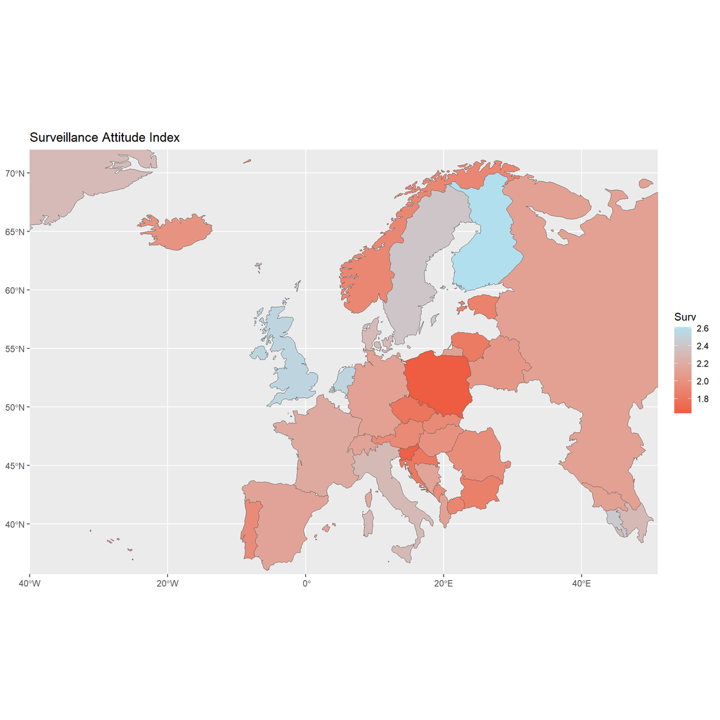

```r
library(ggplot2)
ggplot(data = world) +
  geom_sf(aes(fill = surv)) +
  coord_sf(xlim = c(-40, 51), ylim = c(35.7, 72), expand = FALSE) +
  scale_fill_gradient(low = "tomato2", high = "lightblue2") +
  labs(fill = "Surv") + ggtitle("Surveillance Attitude Index")
```

### Correlational Analysis

#### Scatter plots for dependent and independent variables:

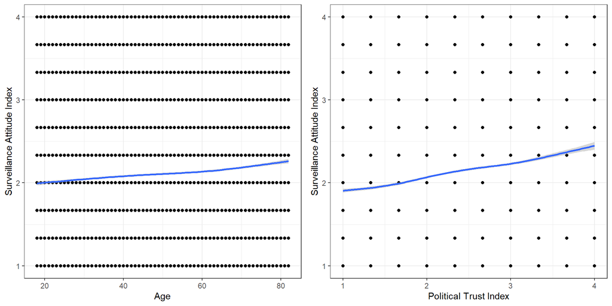

```r
sca1 = ggplot(EVS, aes(x = age, y = surv)) + geom_point() +
  xlab("Age") + ylab("Surveillance Attitude Index") +
  geom_smooth() + theme_bw()

sca2 = ggplot(EVS, aes(x = polit, y = surv)) + geom_point() +
  xlab("Political Trust Index") + ylab("Surveillance Attitude Index") +
  geom_smooth() + theme_bw()

grid_sc <- cowplot::plot_grid(sca1, sca2)
cowplot::plot_grid(grid_sc, ncol = 1, rel_heights = c(0.1, 1))
```

#### Correlation:

```r
corr_data <- data.frame(EVS$surv, EVS$age, EVS$polit)
colnames(corr_data) <- c("Surveillance Attitude Index", "Age", "Political Trust Index")
cor <- cor(corr_data, method = "kendall", use = "pairwise.complete.obs")
```

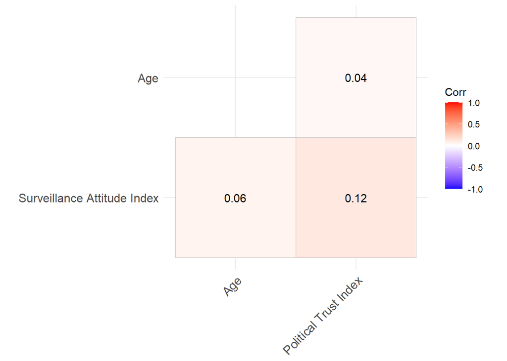

```r
library(ggcorrplot)
ggcorrplot(cor, type = "lower", lab = TRUE)
```

### Statistical test for means’ comparison

#### By Gender:

```r
wilcox.test(EVS$surv ~ EVS$gender)
```

```
##
##  Wilcoxon rank sum test with continuity correction
##
## data:  EVS$surv by EVS$gender
## W = 353210609, p-value = 1.509e-05
## alternative hypothesis: true location shift is not equal to 0
```

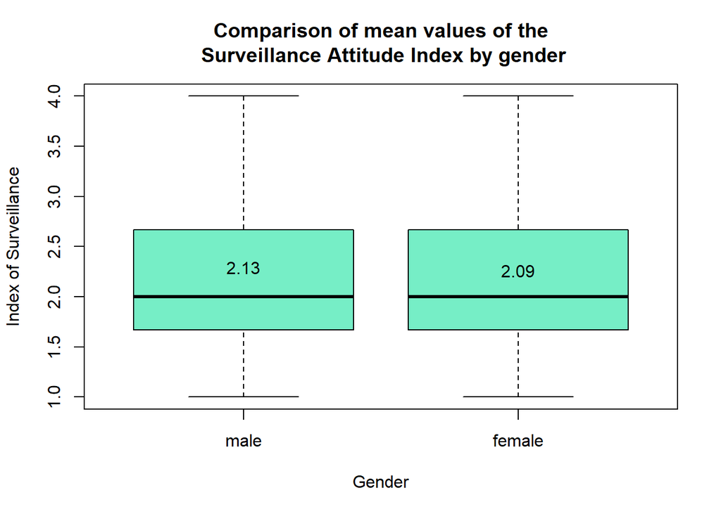

```r
boxplot(EVS$surv~EVS$gender,
        col = "aquamarine2",
        xlab = "Gender",
        ylab = "Index of Surveillance",
        main = "Comparison of mean values of the\n Surveillance Attitude Index by gender")

means <- aggregate(surv ~ gender, data = EVS, FUN = mean)
text(x = seq_along(means$gender), y = means$surv, labels = round(means$surv, 2),
     pos = 3, offset = 0.5)
```

#### By Income:

```r
kruskal.test(surv ~ income, data = EVS)
```

```
##
##  Kruskal-Wallis rank sum test
##
## data:  surv by income
## Kruskal-Wallis chi-squared = 6.0473, df = 2, p-value = 0.04862
```

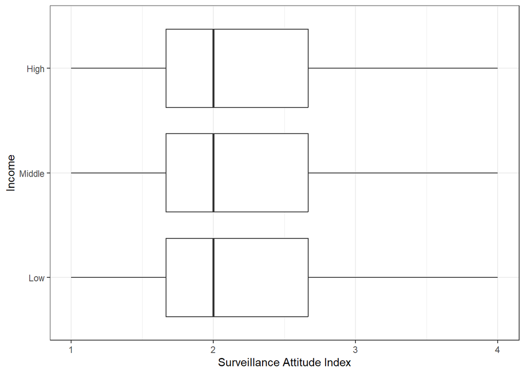

```r
EVS[c("surv", "income")] %>% na.omit() %>%
ggplot() +
  geom_boxplot(aes(x = surv, y = income)) +
  xlab("Surveillance Attitude Index") + ylab("Income") + theme_bw()
```

```r
library(FSA)
dunnTest(EVS$surv,EVS$income, method = "bonferroni")
```

```
##      Comparison         Z    P.unadj      P.adj
## 1    Low - High  2.459122 0.01392771 0.04178314
## 2  Low - Middle  1.245659 0.21288969 0.63866907
## 3 High - Middle -1.238524 0.21552185 0.64656555
```

There is a statistical difference in mean values of Surveillance Attitude Index  
between groups with low and high income.

```r
EVS$income <- as.factor(EVS$income)
EVS %>% dplyr::group_by(income) %>% summarize(mean = mean(surv, na.rm = T)) %>%
  as.data.frame() %>%
  setNames(c("Income", "Mean of the Surveillance Attitude Index")) %>%
  kbl() %>%
  kable_classic(html_font = "Cambria")
```

| Income | Mean of the Surveillance Attitude Index |
| --- | --- |
| Low | 2.143324 |
| Middle | 2.125845 |
| High | 2.113662 |
| NA | 1.998576 |

#### By Size of town:

```r
kruskal.test(surv ~ size_town, data = EVS)
```

```
##
##  Kruskal-Wallis rank sum test
##
## data:  surv by size_town
## Kruskal-Wallis chi-squared = 24.851, df = 4, p-value = 5.391e-05
```

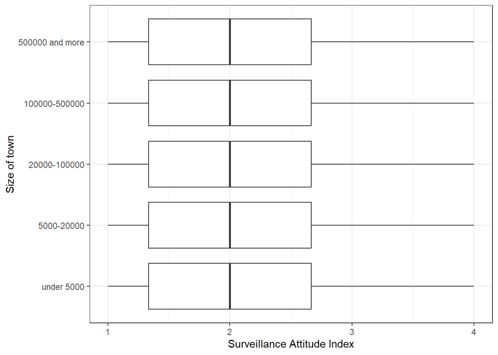

```r
EVS[c("surv", "size_town")] %>% na.omit() %>%
ggplot() +
  geom_boxplot(aes(x = surv, y = size_town)) +
  xlab("Surveillance Attitude Index") + ylab("Size of town") + theme_bw()
```

```r
dunnTest(EVS$surv, EVS$size_town, method = "bonferroni")
```

```
##                         Comparison          Z      P.unadj        P.adj
## 1     100000-500000 - 20000-100000 -1.7002408 8.908563e-02 8.908563e-01
## 2       100000-500000 - 5000-20000 -2.5202738 1.172636e-02 1.172636e-01
## 3        20000-100000 - 5000-20000 -0.8530032 3.936575e-01 1.000000e+00
## 4  100000-500000 - 500000 and more  2.1076769 3.505895e-02 3.505895e-01
## 5   20000-100000 - 500000 and more  3.7816651 1.557829e-04 1.557829e-03
## 6     5000-20000 - 500000 and more  4.5576505 5.172902e-06 5.172902e-05
## 7       100000-500000 - under 5000 -0.1515112 8.795725e-01 1.000000e+00
## 8        20000-100000 - under 5000  1.7773166 7.551617e-02 7.551617e-01
## 9          5000-20000 - under 5000  2.7222879 6.483163e-03 6.483163e-02
## 10    500000 and more - under 5000 -2.4636655 1.375244e-02 1.375244e-01
```

```r
EVS %>% dplyr::group_by(size_town) %>% summarize(mean = mean(surv, na.rm = T)) %>%
  as.data.frame() %>%
  setNames(c("Size of town", "Mean of the Surveillance Attitude Index")) %>%
  kbl() %>%
  kable_classic(html_font = "Cambria")
```

| Size of town | Mean of the Surveillance Attitude Index |
| --- | --- |
| under 5000 | 2.063841 |
| 5000-20000 | 2.089904 |
| 20000-100000 | 2.075583 |
| 100000-500000 | 2.056245 |
| 500000 and more | 2.029074 |
| NA | 2.470090 |

#### By Education:

```r
kruskal.test(surv ~ education, data = EVS)
```

```
##
##  Kruskal-Wallis rank sum test
##
## data:  surv by education
## Kruskal-Wallis chi-squared = 87.667, df = 2, p-value < 2.2e-16
```

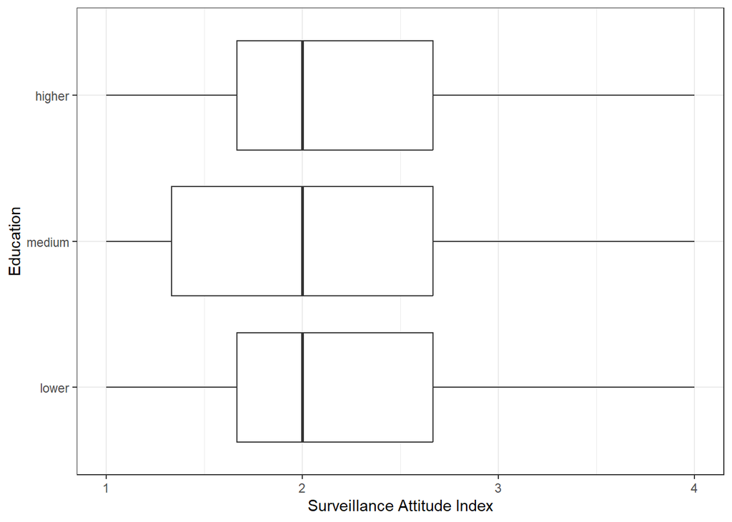

```r
EVS[c("surv", "education")] %>% na.omit() %>%
ggplot() +
  geom_boxplot(aes(x = surv, y = education)) +
  xlab("Surveillance Attitude Index") + ylab("Education") + theme_bw()
```

```r
dunnTest(EVS$surv, EVS$education, method = "bonferroni")
```

```
##        Comparison         Z      P.unadj        P.adj
## 1  higher - lower -5.886477 3.945136e-09 1.183541e-08
## 2 higher - medium  3.757746 1.714505e-04 5.143515e-04
## 3  lower - medium  9.353687 8.464434e-21 2.539330e-20
```

```r
EVS %>% dplyr::group_by(education) %>% summarize(mean = mean(surv, na.rm = T)) %>%
  as.data.frame() %>%
  setNames(c("Education", "Mean of the Surveillance Attitude Index")) %>%
  kbl() %>%
  kable_classic(html_font = "Cambria")
```

| Education | Mean of the Surveillance Attitude Index |
| --- | --- |
| lower | 2.179560 |
| medium | 2.081157 |
| higher | 2.105799 |

# Hypotheses testing

#### H1: The level of political trust is positively associated with the approval of government surveillance;

#### H2: The level of political trust has a stronger influence on the approval of surveillance in post-communist countries than in Western European countries;

#### H3: Age has a stronger influence on the approval of surveillance in Western European countries than in post-communist countries.

### Models 1 & 2

```r
library(sjPlot)
m1 <- lm(surv ~ polit, data = EVS)
tab_model(m1)
```

|  | surv |  |  |
| --- | --- | --- | --- |
| Predictors | Estimates | CI | p |
| (Intercept) | 1.72 | 1.69 – 1.74 | **<0.001** |
| polit | 0.18 | 0.17 – 0.18 | **<0.001** |
| Observations | 49831 |  |  |
| R<sup>2</sup> / R<sup>2</sup> adjusted | 0.024 / 0.024 |  |  |

```r
m2 <- lm(surv ~ polit*part, data = EVS)
tab_model(m2)
```

|  | surv |  |  |
| --- | --- | --- | --- |
| Predictors | Estimates | CI | p |
| (Intercept) | 1.62 | 1.59 – 1.65 | **<0.001** |
| polit | 0.18 | 0.17 – 0.19 | **<0.001** |
| part [West] | 0.37 | 0.32 – 0.42 | **<0.001** |
| polit * part [West] | -0.08 | -0.10 – -0.06 | **<0.001** |
| Observations | 49831 |  |  |
| R<sup>2</sup> / R<sup>2</sup> adjusted | 0.038 / 0.038 |  |  |

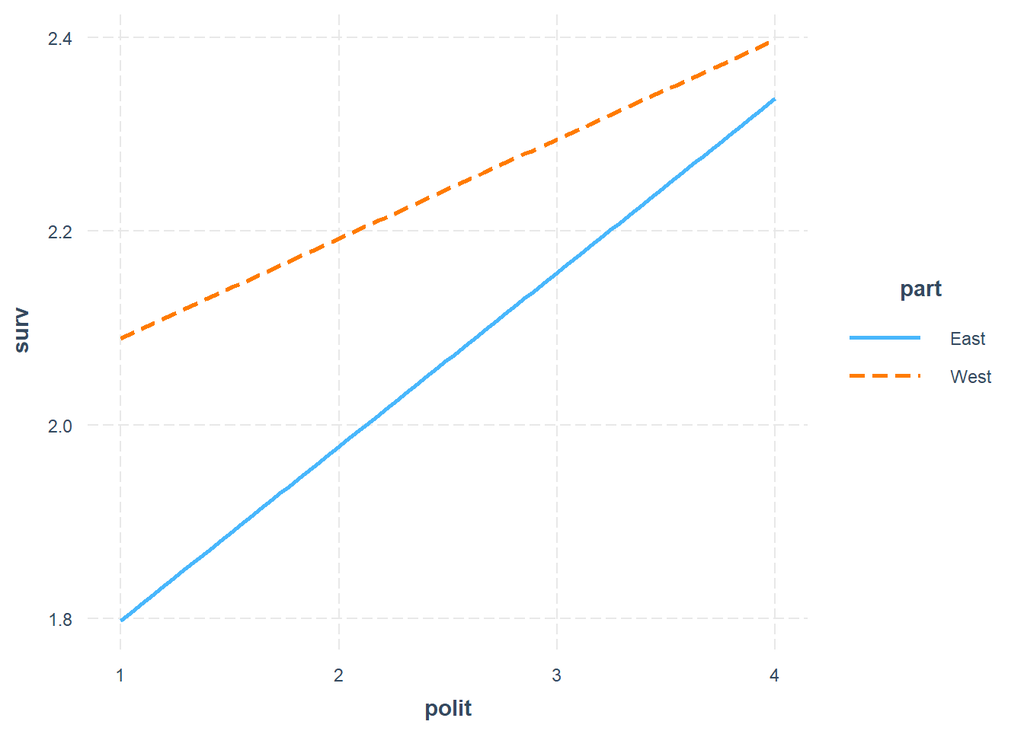

```r
library(interactions)
interact_plot(m2, pred = polit, modx = part, plot.points = F)
```

#### Check for multicollinearity:

```r
vif(m2) %>%
  as.data.frame() %>%
  setNames(c("VIF")) %>%
  kbl() %>%
  kable_classic(html_font = "Cambria")
```

|  | VIF |
| --- | --- |
| polit | 1.720695 |
| part | 12.640377 |
| polit:part | 14.365142 |

There is a multicollinearity presence for interaction effect.

#### Leverage-Residual Plots:

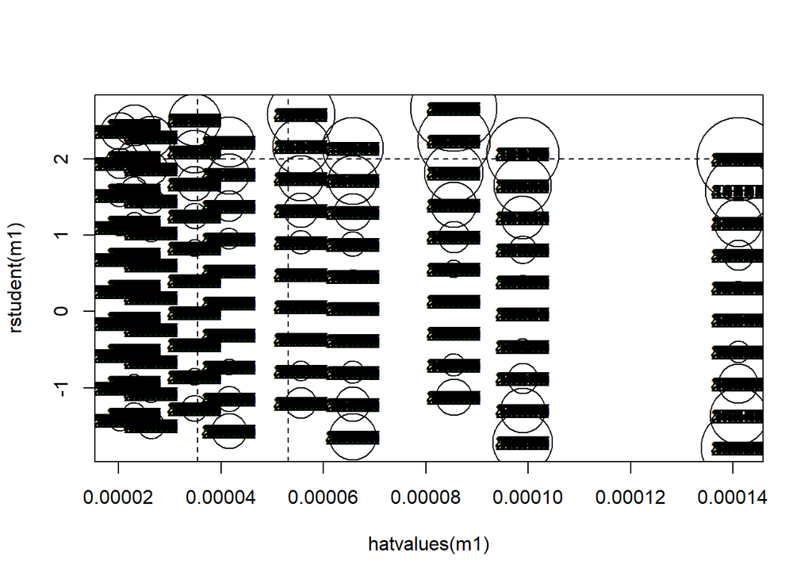

```r
plot(hatvalues(m1), rstudent(m1), type = 'n')
#thresholds for residuals

abline(h = c(-2, 2), lty = 2)
#thresholds for leverages

abline(v = c(2,3)*1/56407, lty = 2)

cook <- sqrt(cooks.distance(m1))
points(hatvalues(m1), rstudent(m1), cex = 10*cook/max(cook))
text(hatvalues(m1), rstudent(m1))
```

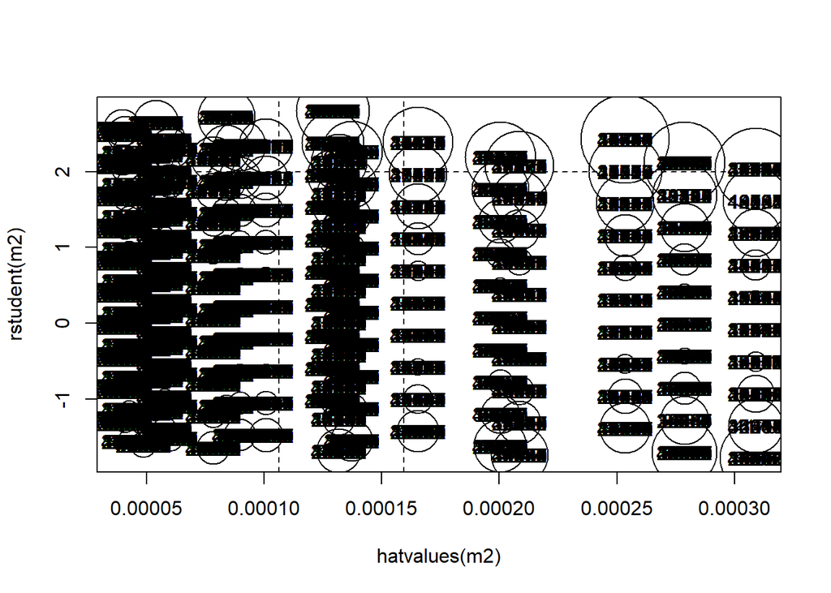

```r
plot(hatvalues(m2), rstudent(m2), type = 'n')
#thresholds for residuals

abline(h = c(-2, 2), lty = 2)
#thresholds for leverages

abline(v = c(2,3)*3/56407, lty = 2)

cook <- sqrt(cooks.distance(m2))
points(hatvalues(m2), rstudent(m2), cex = 10*cook/max(cook))
text(hatvalues(m2), rstudent(m2))
```

#### Residuals distribution:

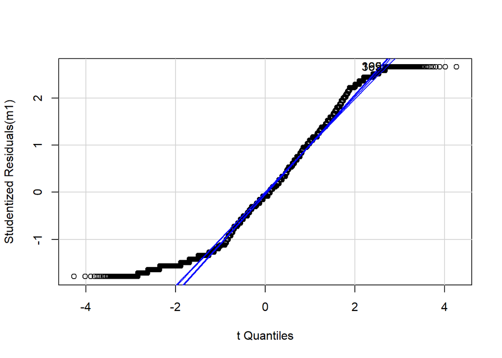

```
## [1] 195 369
```

```r
qqPlot(m1)
```

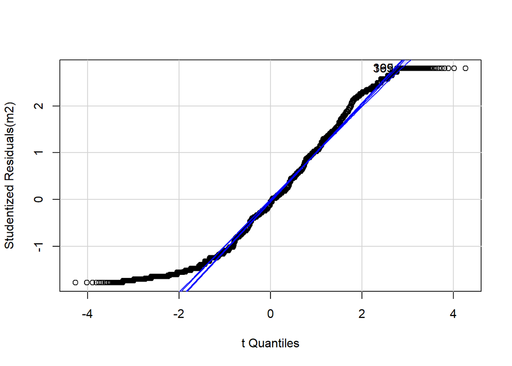

```
## [1] 195 369
```

```r
qqPlot(m2)
```

#### Tests for non-constant variances:

```r
ncvTest(m1)
```

```
## Non-constant Variance Score Test
## Variance formula: ~ fitted.values
## Chisquare = 5.046965, Df = 1, p = 0.024669
```

```r
library(lmtest)
bptest(m1, data = EVS, studentize = T)
```

```
##
##  studentized Breusch-Pagan test
##
## data:  m1
## BP = 6.4811, df = 1, p-value = 0.0109
```

There is a heteroscedasticity presence.

```r
ncvTest(m2)
```

```
## Non-constant Variance Score Test
## Variance formula: ~ fitted.values
## Chisquare = 23.91459, Df = 1, p = 1.0071e-06
```

```r
bptest(m2, data = EVS, studentize = T)
```

```
##
##  studentized Breusch-Pagan test
##
## data:  m2
## BP = 129.88, df = 3, p-value < 2.2e-16
```

There is a heteroscedasticity in this model, too.

#### Residuals plots:

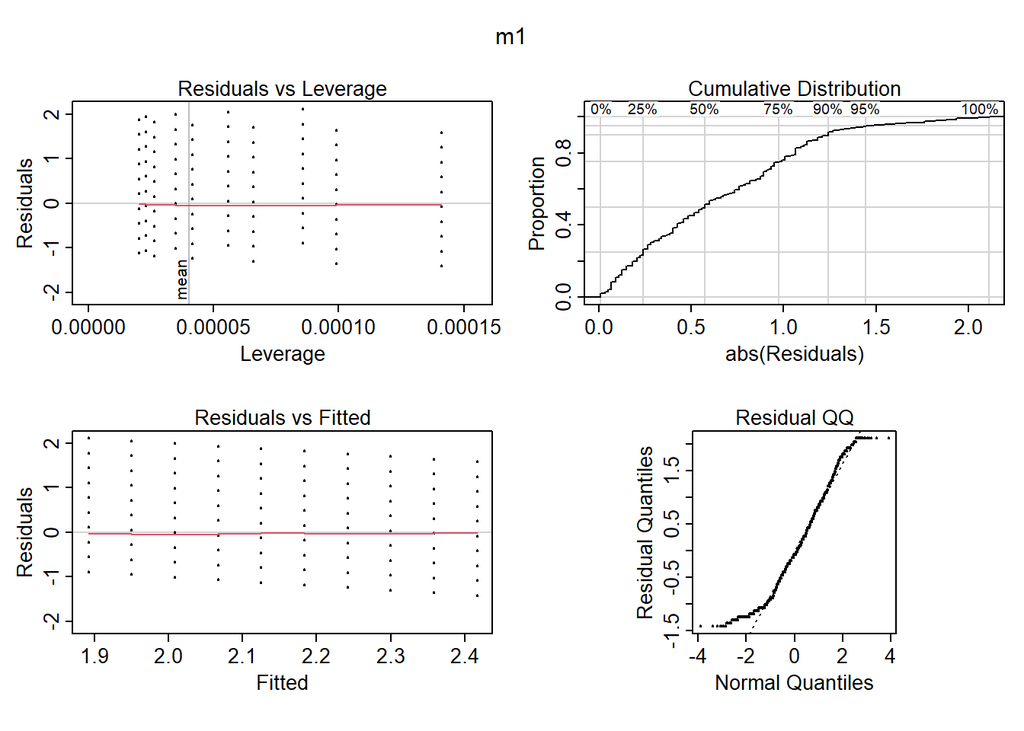

```r
library(plotmo)
plotres(m1, which = 1:4, caption = "m1")
```

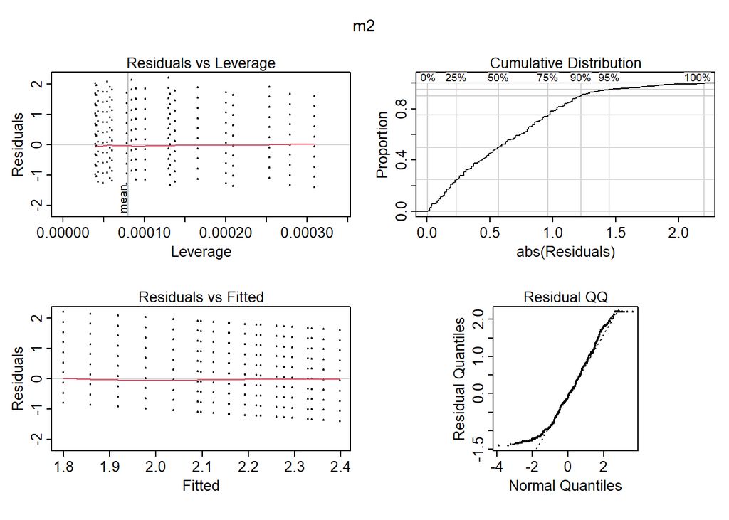

```r
plotres(m2, which = 1:4, caption = "m2")
```

### Model 3

```r
m3 <- lm(surv ~ polit + gender + income + size_town + education + age, data = EVS)
tab_model(m3)
```

|  | surv |  |  |
| --- | --- | --- | --- |
| Predictors | Estimates | CI | p |
| (Intercept) | 1.67 | 1.63 – 1.72 | **<0.001** |
| polit | 0.16 | 0.15 – 0.18 | **<0.001** |
| gender [female] | -0.03 | -0.05 – -0.02 | **<0.001** |
| income [Middle] | -0.01 | -0.03 – 0.01 | 0.578 |
| income [High] | -0.02 | -0.04 – 0.00 | 0.082 |
| size_town5000-20000 | 0.03 | 0.01 – 0.05 | **0.016** |
| size_town20000-100000 | 0.01 | -0.01 – 0.04 | 0.206 |
| size_town100000-500000 | 0.02 | -0.00 – 0.05 | 0.112 |
| size town [500000 and more] | -0.00 | -0.03 – 0.03 | 0.946 |
| education [medium] | -0.06 | -0.08 – -0.03 | **<0.001** |
| education [higher] | -0.08 | -0.11 – -0.06 | **<0.001** |
| age | 0.00 | 0.00 – 0.00 | **<0.001** |
| Observations | 38077 |  |  |
| R<sup>2</sup> / R<sup>2</sup> adjusted | 0.026 / 0.026 |  |  |

#### Check for multicollinearity:

```r
vif(m3)
```

```
##               GVIF Df GVIF^(1/(2*Df))
## polit     1.015241  1        1.007592
## gender    1.008212  1        1.004098
## income    1.138571  2        1.032976
## size_town 1.048722  4        1.005964
## education 1.173539  2        1.040817
## age       1.062930  1        1.030985
```

#### Residuals distribution:

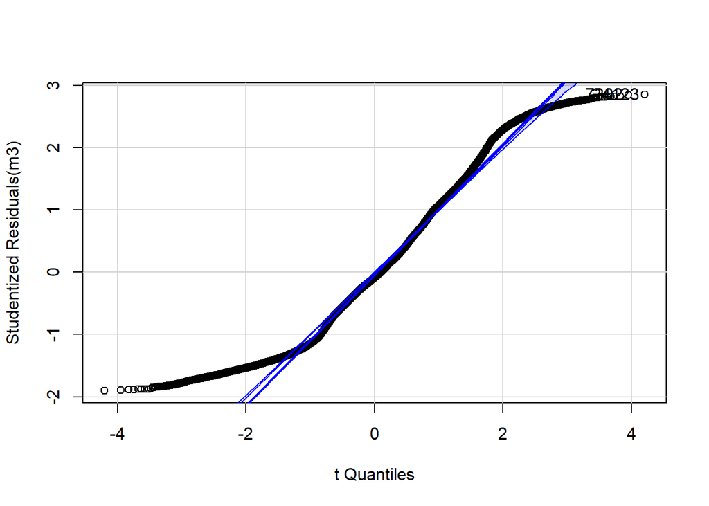

```
## [1]  7202 24123
```

```r
qqPlot(m3)
```

```r
ncvTest(m3)
```

```
## Non-constant Variance Score Test
## Variance formula: ~ fitted.values
## Chisquare = 4.235906, Df = 1, p = 0.039577
```

```r
bptest(m3, data = EVS, studentize = T)
```

```
##
##  studentized Breusch-Pagan test
##
## data:  m3
## BP = 267.8, df = 11, p-value < 2.2e-16
```

There is a heteroscedasticity presence.

#### Residuals plots:

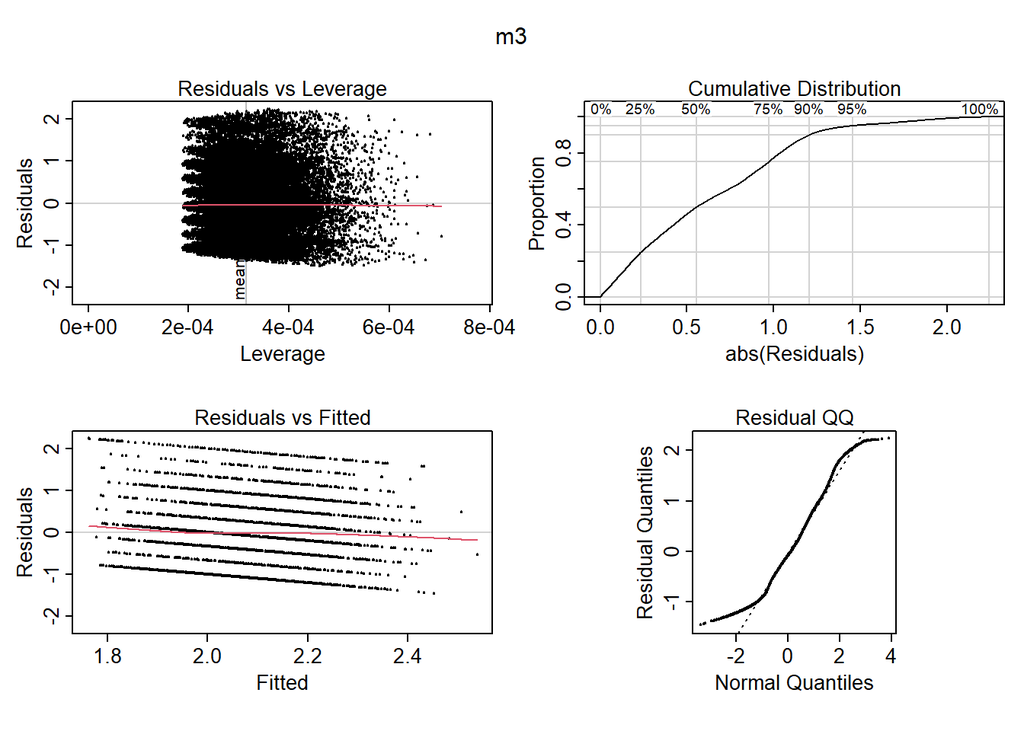

```r
plotres(m3, which = 1:4, caption = "m3")
```

### Model 4

```r
m4 <- lm(surv ~ gender + income + size_town + education + age + polit*part, data = EVS)
tab_model(m4)
```

|  | surv |  |  |
| --- | --- | --- | --- |
| Predictors | Estimates | CI | p |
| (Intercept) | 1.60 | 1.56 – 1.65 | **<0.001** |
| gender [female] | -0.03 | -0.04 – -0.01 | **0.002** |
| income [Middle] | -0.00 | -0.02 – 0.02 | 0.710 |
| income [High] | -0.01 | -0.04 – 0.01 | 0.166 |
| size_town5000-20000 | 0.01 | -0.01 – 0.03 | 0.344 |
| size_town20000-100000 | 0.00 | -0.02 – 0.03 | 0.859 |
| size_town100000-500000 | 0.01 | -0.02 – 0.03 | 0.669 |
| size town [500000 and more] | -0.01 | -0.04 – 0.02 | 0.526 |
| education [medium] | -0.04 | -0.07 – -0.02 | **<0.001** |
| education [higher] | -0.07 | -0.10 – -0.05 | **<0.001** |
| age | 0.00 | 0.00 – 0.00 | **<0.001** |
| polit | 0.18 | 0.16 – 0.19 | **<0.001** |
| part [West] | 0.32 | 0.26 – 0.38 | **<0.001** |
| polit * part [West] | -0.09 | -0.11 – -0.06 | **<0.001** |
| Observations | 38077 |  |  |
| R<sup>2</sup> / R<sup>2</sup> adjusted | 0.032 / 0.032 |  |  |

#### Check for multicollinearity:

```r
vif(m4)
```

```
##                 GVIF Df GVIF^(1/(2*Df))
## gender      1.012223  1        1.006093
## income      1.141987  2        1.033749
## size_town   1.076863  4        1.009300
## education   1.186747  2        1.043733
## age         1.065455  1        1.032209
## polit       1.573323  1        1.254322
## part       13.694115  1        3.700556
## polit:part 15.286740  1        3.909826
```

There is a multicollinearity presence for interaction effect.

#### Residuals distribution:

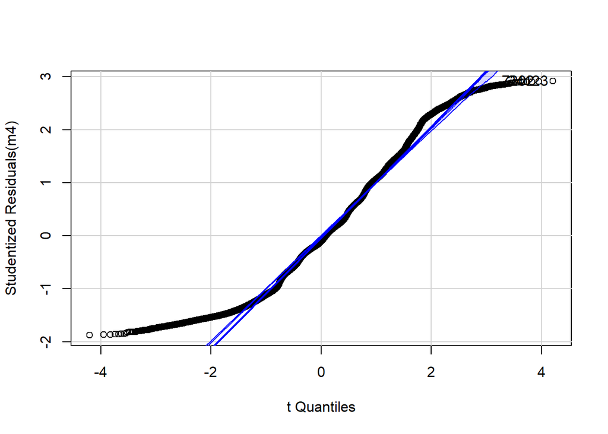

```
## [1]  7202 24123
```

```r
qqPlot(m4)
```

```r
ncvTest(m4)
```

```
## Non-constant Variance Score Test
## Variance formula: ~ fitted.values
## Chisquare = 2.508194, Df = 1, p = 0.11326
```

```r
bptest(m4, data = EVS, studentize = T)
```

```
##
##  studentized Breusch-Pagan test
##
## data:  m4
## BP = 476.71, df = 13, p-value < 2.2e-16
```

Based on non-constant variance test there is no heteroscedasticity,  
but studentized Breusch-Pagan test shows that there is a heteroscedasticity.

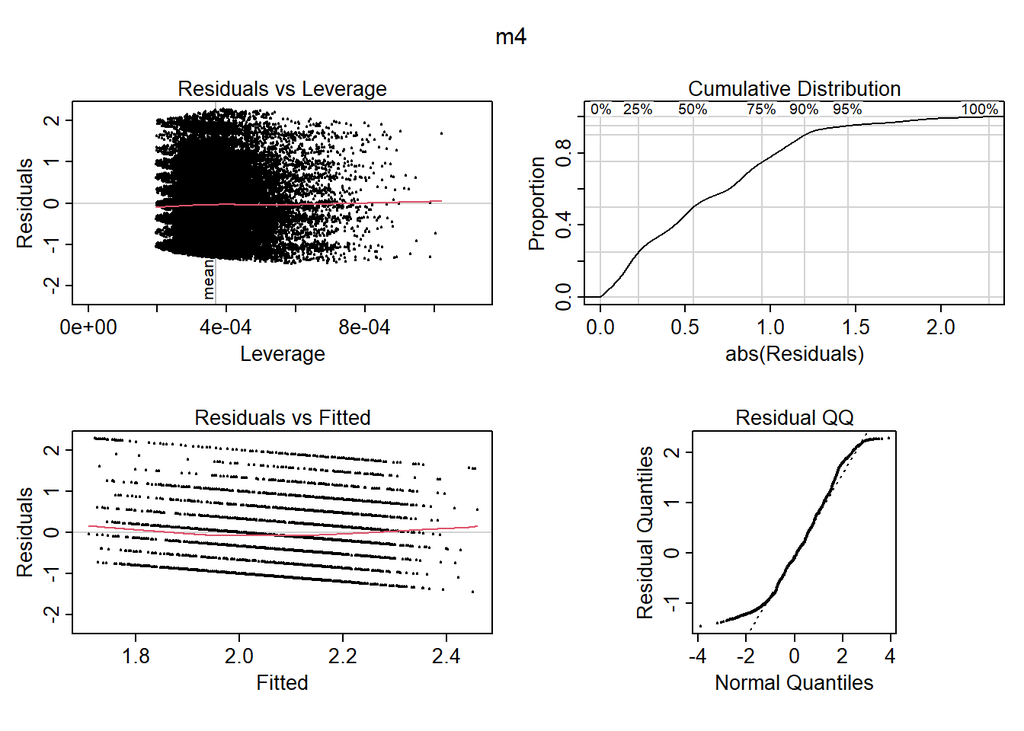

```r
plotres(m4, which = 1:4, caption = "m4")
```

### Model 5

```r
m5 <- lm(surv ~ polit + gender + income + size_town + education + age*part, data = EVS)
tab_model(m5)
```

|  | surv |  |  |
| --- | --- | --- | --- |
| Predictors | Estimates | CI | p |
| (Intercept) | 1.73 | 1.69 – 1.78 | **<0.001** |
| polit | 0.15 | 0.14 – 0.16 | **<0.001** |
| gender [female] | -0.02 | -0.04 – -0.01 | **0.002** |
| income [Middle] | -0.01 | -0.03 – 0.01 | 0.382 |
| income [High] | -0.02 | -0.04 – -0.00 | **0.022** |
| size_town5000-20000 | 0.01 | -0.02 – 0.03 | 0.583 |
| size_town20000-100000 | -0.00 | -0.02 – 0.02 | 0.973 |
| size_town100000-500000 | 0.01 | -0.02 – 0.03 | 0.690 |
| size town [500000 and more] | -0.01 | -0.04 – 0.02 | 0.567 |
| education [medium] | -0.04 | -0.07 – -0.02 | **<0.001** |
| education [higher] | -0.08 | -0.10 – -0.05 | **<0.001** |
| age | 0.00 | 0.00 – 0.00 | **0.012** |
| part [West] | -0.04 | -0.09 – 0.01 | 0.130 |
| age * part [West] | 0.00 | 0.00 – 0.00 | **<0.001** |
| Observations | 38077 |  |  |
| R<sup>2</sup> / R<sup>2</sup> adjusted | 0.032 / 0.031 |  |  |

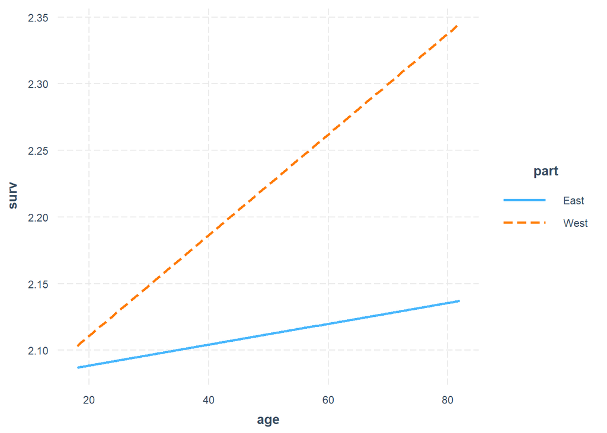

```r
interact_plot(m5, pred = age, modx = part, plot.points = FALSE)
```

```r
vif(m5)
```

```
##                GVIF Df GVIF^(1/(2*Df))
## polit      1.060444  1        1.029779
## gender     1.012613  1        1.006287
## income     1.146634  2        1.034799
## size_town  1.074273  4        1.008996
## education  1.181658  2        1.042612
## age        1.803918  1        1.343100
## part       9.304226  1        3.050283
## age:part  10.258635  1        3.202910
```

There is a multicollinearity presence for interaction effect.

#### Residuals distribution:

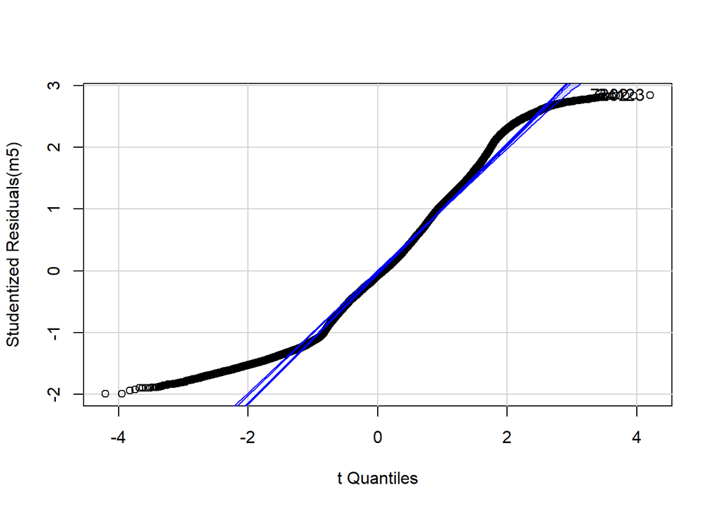

```
## [1]  7202 24123
```

```r
qqPlot(m5)
```

```r
ncvTest(m5)
```

```
## Non-constant Variance Score Test
## Variance formula: ~ fitted.values
## Chisquare = 5.369026, Df = 1, p = 0.020497
```

```r
bptest(m5, data = EVS, studentize = T)
```

```
##
##  studentized Breusch-Pagan test
##
## data:  m5
## BP = 446.62, df = 13, p-value < 2.2e-16
```

Based on non-constant variance test and studentized Breusch-Pagan test, there is a heteroscedasticity.

#### Residuals plots:

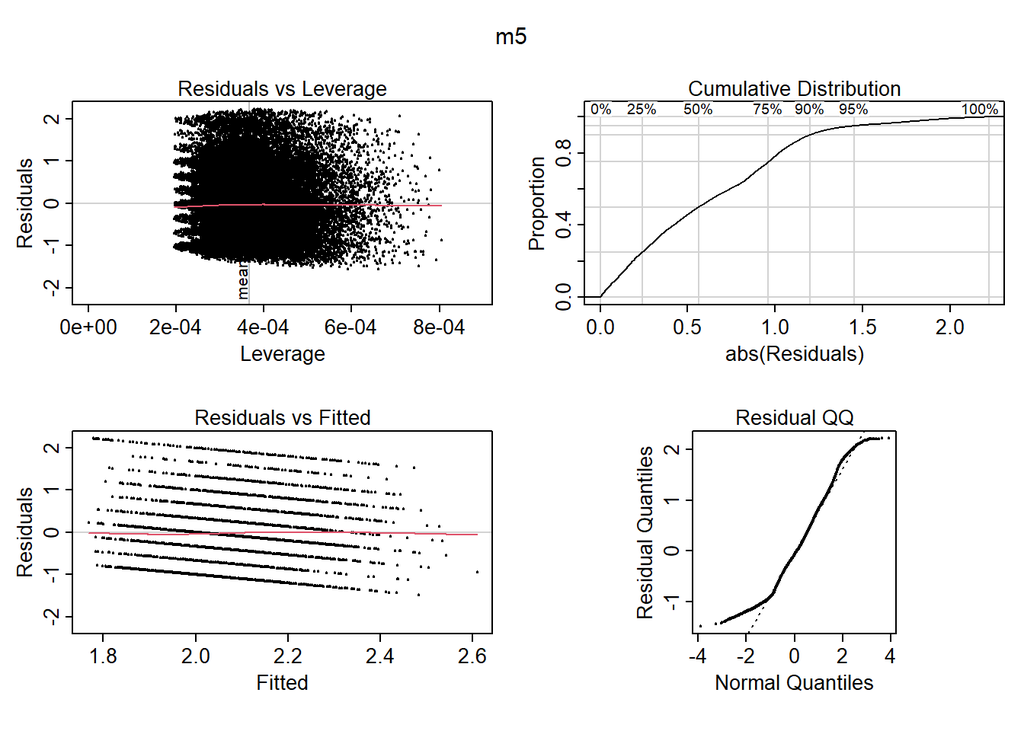

```r
plotres(m5, which = 1:4, caption = "m5")
```

### Non-constant error variance

(Heteroscedasticity)

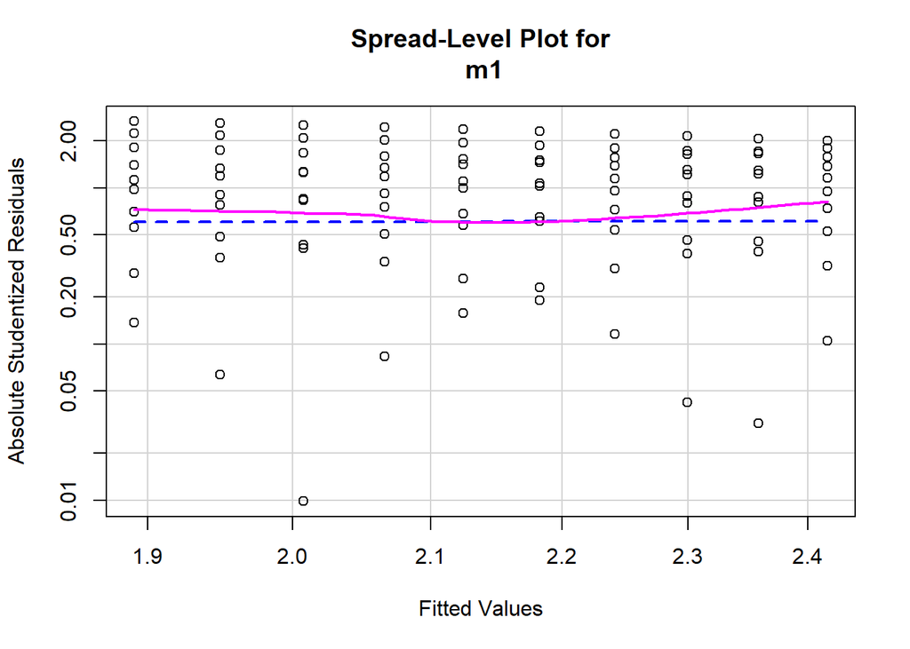

```
##
## Suggested power transformation:  0.9283661
```

```r
spreadLevelPlot(m1)
```

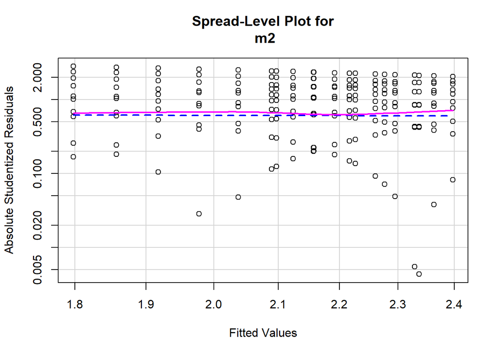

```
##
## Suggested power transformation:  1.075692
```

```r
spreadLevelPlot(m2)
```

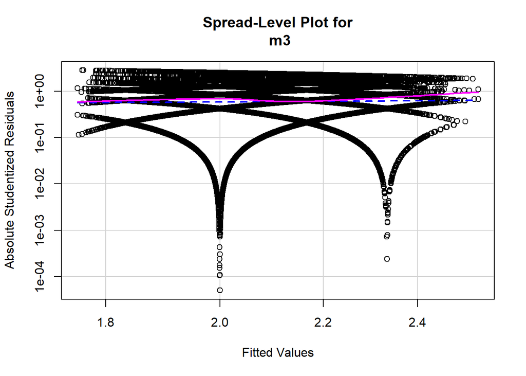

```
##
## Suggested power transformation:  0.6896175
```

```r
spreadLevelPlot(m3)
```

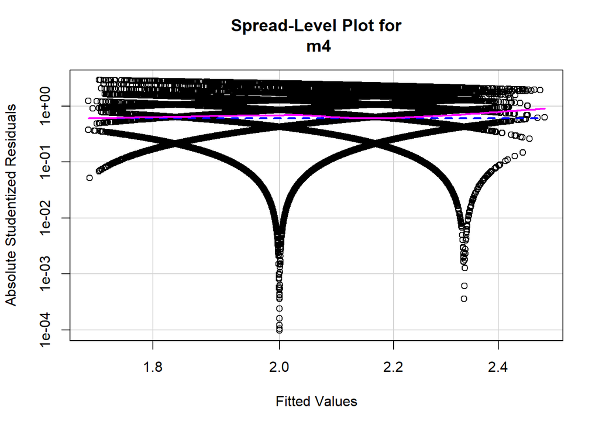

```
##
## Suggested power transformation:  0.9835075
```

```r
spreadLevelPlot(m4)
```

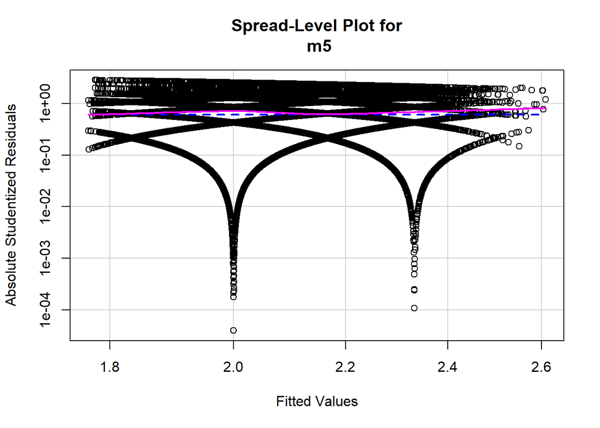

```
##
## Suggested power transformation:  0.9882116
```

```r
spreadLevelPlot(m5)
```

As there is a heteroscedasticity present, we need to use inference for estimated coefficients  
with a heteroscedasticity-consistent covariance matrix.

### Inference for Estimated Coefs

```r
library(sandwich)
coeftest(m1, vcovHC(m1, "HC1"))
```

```
##
## t test of coefficients:
##
##              Estimate Std. Error t value  Pr(>|t|)
## (Intercept) 1.7159690  0.0125719 136.493 < 2.2e-16 ***
## polit       0.1751146  0.0052891  33.109 < 2.2e-16 ***
## ---
## Signif. codes:  0 '***' 0.001 '**' 0.01 '*' 0.05 '.' 0.1 ' ' 1
```

```r
coeftest(m2, vcovHC(m2, "HC1"))
```

```
##
## t test of coefficients:
##
##                  Estimate Std. Error  t value  Pr(>|t|)
## (Intercept)     1.6183286  0.0158464 102.1259 < 2.2e-16 ***
## polit           0.1796040  0.0070957  25.3117 < 2.2e-16 ***
## partWest        0.3686486  0.0262929  14.0208 < 2.2e-16 ***
## polit:partWest -0.0769843  0.0109717  -7.0166 2.302e-12 ***
## ---
## Signif. codes:  0 '***' 0.001 '**' 0.01 '*' 0.05 '.' 0.1 ' ' 1
```

```r
coeftest(m3, vcovHC(m3, "HC1"))
```

```
##
## t test of coefficients:
##
##                             Estimate  Std. Error t value  Pr(>|t|)
## (Intercept)               1.67388524  0.02294246 72.9601 < 2.2e-16 ***
## polit                     0.16443073  0.00601948 27.3164 < 2.2e-16 ***
## genderfemale             -0.03250936  0.00812053 -4.0034 6.257e-05 ***
## incomeMiddle             -0.00558887  0.01021306 -0.5472   0.58423
## incomeHigh               -0.01837277  0.01061288 -1.7312   0.08343 .
## size_town5000-20000       0.02746970  0.01157773  2.3726   0.01767 *
## size_town20000-100000     0.01474781  0.01161437  1.2698   0.20417
## size_town100000-500000    0.02017949  0.01267041  1.5926   0.11125
## size_town500000 and more -0.00095113  0.01395218 -0.0682   0.94565
## educationmedium          -0.05545011  0.01207569 -4.5919 4.407e-06 ***
## educationhigher          -0.08038537  0.01296347 -6.2009 5.671e-10 ***
## age                       0.00218146  0.00023982  9.0961 < 2.2e-16 ***
## ---
## Signif. codes:  0 '***' 0.001 '**' 0.01 '*' 0.05 '.' 0.1 ' ' 1
```

```r
coeftest(m4, vcovHC(m4, "HC1"))
```

```
##
## t test of coefficients:
##
##                            Estimate Std. Error t value  Pr(>|t|)
## (Intercept)               1.6029250  0.0254179 63.0628 < 2.2e-16 ***
## genderfemale             -0.0256701  0.0081188 -3.1618 0.0015692 **
## incomeMiddle             -0.0037262  0.0102017 -0.3652 0.7149288
## incomeHigh               -0.0146234  0.0106132 -1.3778 0.1682581
## size_town5000-20000       0.0108938  0.0116568  0.9345 0.3500333
## size_town20000-100000     0.0020804  0.0116301  0.1789 0.8580350
## size_town100000-500000    0.0054355  0.0127609  0.4259 0.6701493
## size_town500000 and more -0.0088791  0.0139410 -0.6369 0.5241886
## educationmedium          -0.0435377  0.0120832 -3.6031 0.0003148 ***
## educationhigher          -0.0718465  0.0129784 -5.5359 3.118e-08 ***
## age                       0.0020755  0.0002395  8.6662 < 2.2e-16 ***
## polit                     0.1777100  0.0077159 23.0316 < 2.2e-16 ***
## partWest                  0.3169112  0.0313250 10.1169 < 2.2e-16 ***
## polit:partWest           -0.0881469  0.0128372 -6.8665 6.681e-12 ***
## ---
## Signif. codes:  0 '***' 0.001 '**' 0.01 '*' 0.05 '.' 0.1 ' ' 1
```

```r
coeftest(m5, vcovHC(m5, "HC1"))
```

```
##
## t test of coefficients:
##
##                             Estimate  Std. Error t value  Pr(>|t|)
## (Intercept)               1.73373784  0.02515020 68.9354 < 2.2e-16 ***
## polit                     0.14918154  0.00620292 24.0502 < 2.2e-16 ***
## genderfemale             -0.02487129  0.00812179 -3.0623 0.0021980 **
## incomeMiddle             -0.00875680  0.01021461 -0.8573 0.3912944
## incomeHigh               -0.02422512  0.01062904 -2.2791 0.0226640 *
## size_town5000-20000       0.00631880  0.01164991  0.5424 0.5875526
## size_town20000-100000    -0.00039136  0.01163087 -0.0336 0.9731579
## size_town100000-500000    0.00508516  0.01275951  0.3985 0.6902352
## size_town500000 and more -0.00801508  0.01394813 -0.5746 0.5655418
## educationmedium          -0.04370469  0.01207103 -3.6206 0.0002943 ***
## educationhigher          -0.07590140  0.01293724 -5.8669 4.477e-09 ***
## age                       0.00078191  0.00032532  2.4035 0.0162427 *
## partWest                 -0.03765975  0.02421834 -1.5550 0.1199521
## age:partWest              0.00299597  0.00046695  6.4161 1.415e-10 ***
## ---
## Signif. codes:  0 '***' 0.001 '**' 0.01 '*' 0.05 '.' 0.1 ' ' 1
```

#### All three hypotheses stated here were confirmed.